# Probabilistic Programming in Python

## Dr. Thomas Wiecki

## [@twiecki](http://twitter.com/twiecki)

# About me

- Lead Data Scientist at [Quantopian Inc](https://www.quantopian.com): Building a crowd sourced hedge fund.
- PhD from Brown University -- research on computational neuroscience and machine learning using Bayesian modeling.

# Develop trading strategies in your browser

[figure not shown]

## Live Trading

[figure not shown]

## Crowd-sourced hedge fund

[figure not shown]

# Identify trading algorithms with highest chance of beating the market

```python
for i, algo in enumerate(algos):
    print 'Success algo %i: ' % i, algo
```

```
Success algo 0:  [1 0 1 1 0 0 0 1 0 0 1 1 0 1 1 1 1 0 1 1 1 0 0 1 0 0 1 1 1 1 1 1 1 0 0 0 0
 1 0 1 1 1 0 1 0 1 0 1 0 0 0 0 1 0 0 1 1 0 1 0 1 1 1 1 0 0 0 0 0 1 0 0 0 1
 0 0 1 1 1 0 1 1 1 0 0 0 0 0 1 1 0 0 0 1 0 0 1 0 0 1 1 1 0 0 1 1 1 0 0 1 0
 1 1 0 0 0 0 0 1 0 0 1 0 1 0 1 0 0 1 0 0 1 0 0 1 1 1 1 0 1 1 1 1 1 1 1 0 0
 1 0 0 0 1 1 0 1 1 1 0 0 0 0 0 0 1 1 0 0 1 1 1 1 1 1 1 0 1 0 0 1 0 1 0 0 1
 1 0 0 0 0 0 1 0 0 1 0 1 1 0 0]
Success algo 1:  [1 1 0 1 0 0 1 1 0 1 0 1 1 0 1 0 0 0 0 0 0 1 0 0 1 0 0 1 0 1 0 1 1 0 0 0 0
 0 0 1 0 0 1 0 0 1 0 0 1 0]
Success algo 2:  [0 1 0 0 0 1 1 0 0 0 1 1 1 0 0 1 1 0 0 0 0 1 0 1 1 1 0 1 0 1 1 1 0 0 1 1 0
 1 1 1 1 0 1 1 0 0 0 0 1 1 0 1 0 1 0 1 1 1 1 0 1 0 0 1 0 0 1 1 1 1 0 1 1 0
 1 1 1 0 1 1 0 1 1 0 1 0 1 1 0 0 1 0 1 0 1 1 1 1 0 0 0 0 1 0 1 1 1 0 0 1 1
 1 0 0 1 1 0 1 1 0 1 1 1 1 1 0 0 0 1 0 1 1 0 0 0 1 1 1 1 1 1 1 1 1 1 0 1 0
 1 1]
Success algo 3:  [0 1 1 1 1 1 0 1 1 1 1 0 0 1 1 1 0 1 1 0 0 0 0 0 1]
Success algo 4:  [1 1 0 1 1]
Success algo 5:  [0 1 1 1 1 1 1 0 0 1]
```

# Very general problem -- reddit comment ratings

[figure not shown]

- Simple question: How to rank them?

# The simplest answer

- Take the mean.
- This is equivalent to the maximum likelihood estimate, so statistically not a bad idea.

```python
for i, algo in enumerate(algos):
    print 'Prob of success algo %i: '  % i, np.mean(algo) * 100
```

[output not shown]

# Sort and display

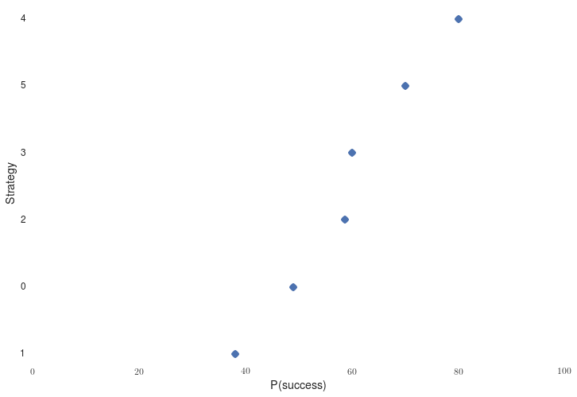

```python
probs = pd.Series({i: np.mean(algo) * 100 for i, algo in enumerate(algos)})
probs.sort(ascending=True)
plt.plot(probs.values, np.arange(len(probs.index)), 'o'); plt.xlabel('P(success)'); plt.ylabel('Strategy'); plt.xlim(0., 100.); plt.ylim(-.1, 5.2); plt.yticks(np.arange(len(probs.index)), probs.index);
```

# How to capture uncertainty?

# Bayesian statistics

- **Flexible statistical framework** that allows **uncertainty quantification**.
- Uses **probability distributions** to reason about unknowns.
- **Not** consider a **single mean** but rather assign **every possible mean** a **probability**.
- Probability distribution: maps **parameter values** to **probabilities**.
- Bayesian statistics updates **probiability distributions** after observing **data**.

[figure not shown]

- "When I bet on horses, I never lose. Why? I bet on all the horses." Tom Haverford

# Probability of the mean without having seen any data.

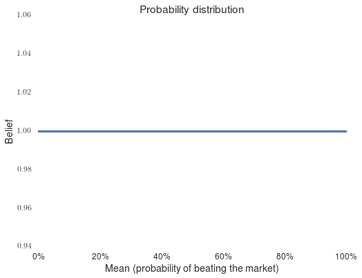

```python
gen_plot(1, 1)
```

# Probability of the mean after having seen 5 successes and 2 failures

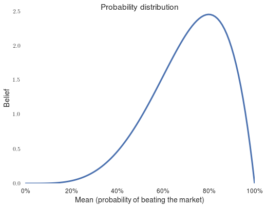

```python
gen_plot(5, 2)
```

# Probability of the mean after having seen 50 successes and 20 failures

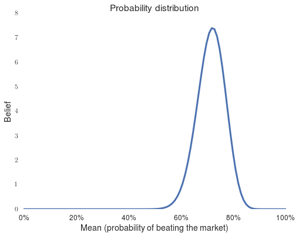

```python
gen_plot(50, 20)
```

# Bayes Formula

[figure not shown]

# PyMC3

- **Probabilistic Programming** framework written in **Python**.
- Allows for construction of probabilistic models using **intuitive syntax**.
- Written by: John Salvatier, Chris Fonnesbeck, Thomas Wiecki
- Upcoming 3.0 release!

## Some necessary formalism:

$\text{mean} \sim \text{Beta}(1, 1)$

$\text{data} \sim \text{Bernoulli}(\text{mean})$

- $\text{mean}$ represents the unkown parameter we want to infer, but can't observe directly.
- Use **data** to **update belief** about **parameter**.

```python
algo = algos[0]
algo
```

[output not shown]

# Model in PyMC3

```python
import pymc3

# Define priors
mean = pymc3.Beta('mean', alpha=1, beta=1) # prior

# Define how mean parameter relates to data
data = pymc3.Bernoulli('observed',
                       p=mean,
                       observed=algo)
```

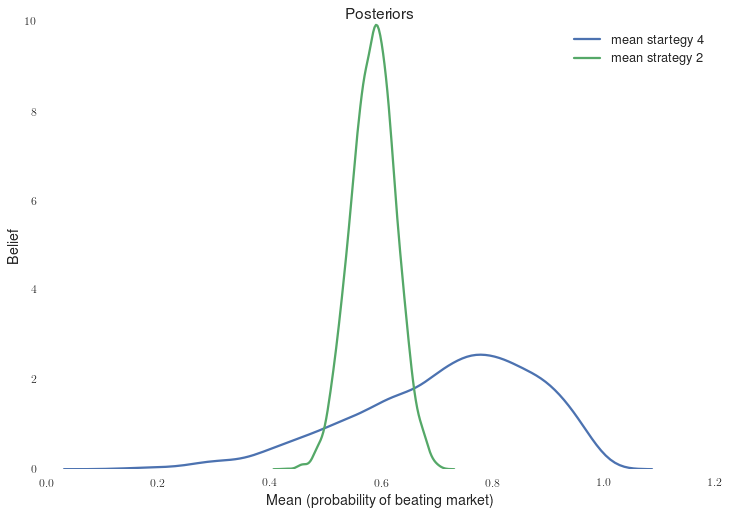

```python
sns.distplot(trace['theta 4'], label='mean startegy 4', hist=False)
sns.distplot(trace['theta 2'], label='mean strategy 2', hist=False)
plt.title('Posteriors'); plt.xlabel('Mean (probability of beating market)'); plt.ylabel('Belief'); plt.legend();
```

## Hypothesis testing

```python
print 'Probability that algo 2 is better than algo 4 = %.2f%%' % (p_2_better_than_4 * 100)
```

```
Probability that algo 2 is better than algo 4 = 20.74%
```

# Sort by mean

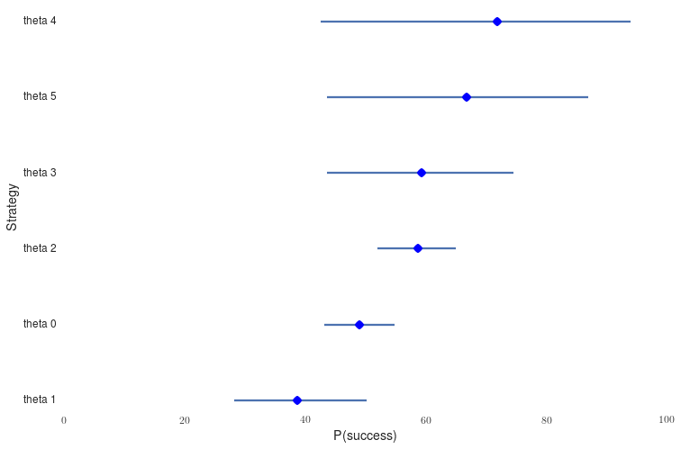

```python
plt.plot(probs.values, np.arange(len(probs.index)), 'bo'); plt.errorbar(probs.values, np.arange(len(probs.index)), xerr=(lower_quant, upper_quant), ls=''); plt.xlabel('P(success)'); plt.ylabel('Strategy'); plt.xlim(0., 100.); plt.ylim(-.1, 5.2); plt.yticks(np.arange(len(probs.index)), probs.index);
```

# Alternatively: Sort by lowest quantile

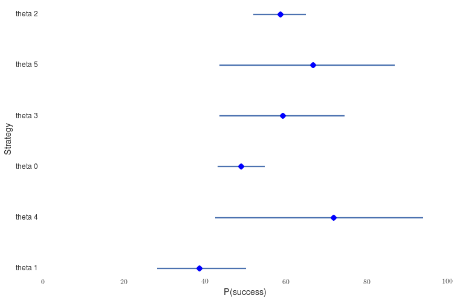

```python
plt.plot(probs.values, np.arange(len(probs.index)), 'bo'); plt.errorbar(probs.values, np.arange(len(probs.index)), xerr=(lower_quant, upper_quant), ls=''); plt.xlabel('P(success)'); plt.ylabel('Strategy'); plt.xlim(0., 100.); plt.ylim(-.1, 5.2); plt.yticks(np.arange(len(probs.index)), probs.index);
```

# Conclusions

- **Probabilistic Programming** allows you to **quantify uncertainty**.
- **Blackbox inference algorithms** allow estimation of **complex models** automatically.
- **PyMC3** puts **advanced samplers** at your fingertips.
- **Big Data**: New class of samplers can work in parallel on subsets of the data.

# Further reading

- [Quantopian](https://www.quantopian.com) -- Develop trading algorithms like this in your browser.
- [My blog for Bayesian linear regression (financial alpha and beta)](https://twiecki.github.io)
- [Probilistic Programming for Hackers](http://camdavidsonpilon.github.io/Probabilistic-Programming-and-Bayesian-Methods-for-Hackers/) -- IPython Notebook book on Bayesian stats using PyMC2.
- [Doing Bayesian Data Analysis](http://www.indiana.edu/~kruschke/DoingBayesianDataAnalysis/) -- Great book by Kruschke.
- [PyMC3 repository](https://github.com/pymc-devs/pymc3)
- Twitter: [@twiecki](https://twitter.com/twiecki)